# Deep Learning, Pretrained Model

- Anita Taucher (agt4vw)

I obtain the pretrained model from huggingface `https://huggingface.co/cardiffnlp/twitter-roberta-base-sentiment`

This model rates sentiment using labels: **0 -> Negative; 1 -> Neutral; 2 -> Positive**

To instantiate the model, I use the following from the huggingface documentation:

`AutoModelForSequenceClassification.from_pretrained()`

`AutoTokenizer.from_pretrained()`

Example documentation is located at https://huggingface.co/cardiffnlp/twitter-roberta-base-sentiment

## Install Needed Libraries

Install PyGitHub to allow reading directly from a github repository where the novel dataset is stored.

```python
!pip install transformers
!pip install PyGitHub
```

[output not shown]

## Get Data Files from Github

Because the data was collected in every-other-day intervals over a period of 9 weeks, there are several data files. Here, the data is loaded directly from the github repo.

```python
## Establish github connection
import pandas as pd
from github import Github

g = Github("MASKED_VALUE")
u = g.get_user("anita-uva")

repo = g.get_repo("anita-uva/ClassifyMediaBias", lazy=False)

## Loop through files in our github "data" directory

## First, get the file names from github data directory
data_files = repo.get_contents("data")

## Get ready to create a list of dataframes
dfs = []
df = pd.DataFrame()

## For each file in our data directory create a dataframe
## Add the dataframe to a list of dataframes
for aFile in data_files:
  if aFile.path.endswith('withbias.csv'):

    file_contents = pd.read_csv(aFile.download_url, usecols=['Title',	'Link',	'Description',	'Pub_Date',	'Publication',	'Bias'])
    dfs.append(file_contents)

## Concatenate our list of dataframes into one
articles = pd.concat(dfs, ignore_index = True).drop_duplicates().dropna(subset=['Bias']).reset_index().drop('index', axis=1)
```

## Drop Unnecessary Data

Even though allsides.com provides article classification for Mixed and Not Rated articles, there are not enough of these types to contribute to our goals. As a result we drop articles with Bias ratings of "Mixed" and "Not Rated". We additionally set our Bias scale as an ordered categorical variable and properly type the Dates.

```python
## let's get rid of these guys, there's just not enough, and they're potentially confusing
articles = articles.drop(articles.index[articles['Bias'] == 'Mixed'])
articles = articles.drop(articles.index[articles['Bias'] == 'Not Rated'])

articles.Bias = pd.Categorical(articles.Bias, ordered=True, categories=['Left', 'Lean Left', 'Center', 'Lean Right', 'Right'])
articles.Pub_Date = pd.to_datetime(articles.Pub_Date)

print('Article Date Range')
display(min(articles.reset_index().Pub_Date.dt.date.unique()))
display(max(articles.reset_index().Pub_Date.dt.date.unique()))

print('\nArticle Bias Range')
display(articles.Bias.unique())

print('\nTotal Number of Articles')
display(len(articles))

print('\nAverage Length of the Article Description in Characters')
import numpy as np
np.mean([len(articles.Description.values[x]) for x in range(0,len(articles))]).round(2)
```

```
Article Date Range
```

```
datetime.date(2022, 6, 11)
```

```
datetime.date(2022, 8, 6)
```

```
Article Bias Range
```

```
['Lean Left', 'Right', 'Center', 'Left', 'Lean Right']
Categories (5, object): ['Left' < 'Lean Left' < 'Center' < 'Lean Right' < 'Right']
```

```
Total Number of Articles
```

```
2011
```

```
Average Length of the Article Description in Characters
```

```
473.82
```

## Provide Basic Summary Statistics

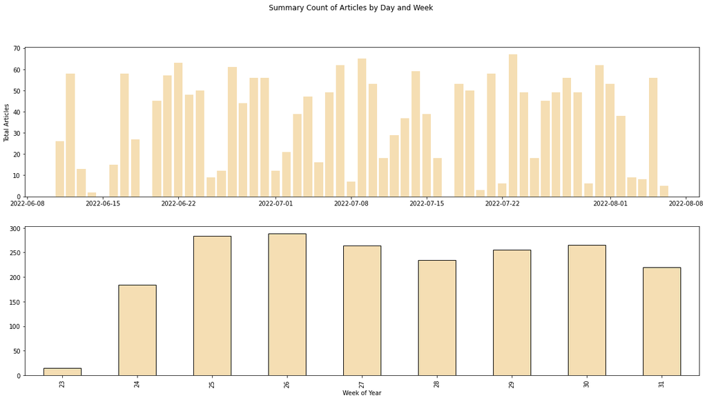

```python
## Distribution of Articles per day and per week.
import matplotlib.pyplot as plt

fig, (ax1, ax2) = plt.subplots(2, 1, figsize=(20, 10))
fig.suptitle('Summary Count of Articles by Day and Week')

# ax1 = articles.Pub_Date.dt.date.value_counts().sort_index().plot(kind='bar', color='wheat')

ax1.bar(articles.Pub_Date.dt.date.unique(), articles.Pub_Date.dt.date.value_counts().sort_index(), color='wheat')
ax1.set_ylabel('Total Articles')

ax2 = articles.Pub_Date.dt.isocalendar().week.value_counts().sort_index().plot(kind='bar', color='wheat', edgecolor = 'black')
ax2.set_xlabel("Week of Year")

plt.show()
```

## Gaussian Distribution across Bias

Our articles show a gaussian distribution across the Bias, with each bias having at least 10% of the entire scope of the dataset, and "Center" having the greatest number of articles.

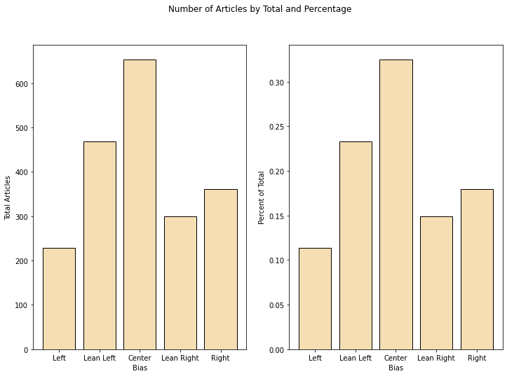

```python
x = articles.Bias.unique().sort_values()

fig, (ax1, ax2) = plt.subplots(1, 2, figsize=(12, 8))
fig.suptitle('Number of Articles by Total and Percentage')

ax1.bar(x, articles.Bias.value_counts().sort_index(), color='wheat', edgecolor = 'black')
ax1.set_ylabel('Total Articles')
ax1.set_xlabel('Bias')

ax2.bar(x, (articles.Bias.value_counts()/len(articles)).sort_index(), color='wheat', edgecolor = 'black' )
ax2.set_xlabel('Bias')
ax2.set_ylabel('Percent of Total')

plt.show()
```

## Count of Articles by Publication

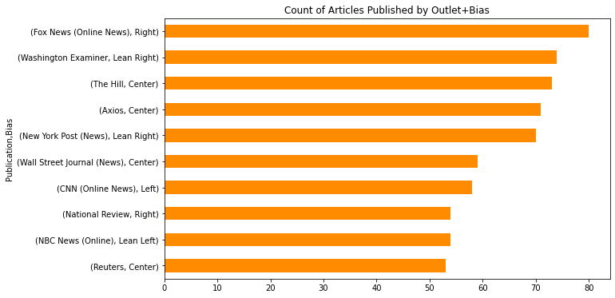

```python
## Who publishes the most stories in our dataset
## The News Outlet and Bias are 100% Correlated.
articles[['Publication', 'Bias']].value_counts().nlargest(10).sort_values().plot(kind='barh', color='darkorange', figsize=(10,6), title="Count of Articles Published by Outlet+Bias")
```

## Prepare for Analysis

The Sentiment Analysis will provide 6 total scores for each article:

- Negative
- Neutral
- Positive
- Negative Percent
- Neutral Percent
- Positive Percent

We perform the Sentiment Analysis separately on Headlines and on Article Descriptions (the first ~475 characters of the article).

We create a headline (hl) dataframe and an article description (ad) dataframe. To those dataframes, we add all 6 scores for each article, so that our headline and article dataframes will hold all 6 scores for each article.

```python
## These are the new statistics we will add to the dataframe
## to add a new field, just add it to this list and it will be
## propagated throughout...

new_stats = ['negative', 'neutral', 'positive', 'negative_pct', 'neutral_pct', 'positive_pct']
```

Create the Headline Dataframe

```python
## Set Up Headlines df, the df name is HL not H one
hl = articles[['Title', 'Pub_Date', 'Publication', 'Bias']].copy()

## Add new fields to the df to be calculated in the text analysis
for new_stat in new_stats:
  hl[new_stat] = hl.apply(lambda r: 0.0)

hl.columns
```

```
Index(['Title', 'Pub_Date', 'Publication', 'Bias', 'negative', 'neutral',
       'positive', 'negative_pct', 'neutral_pct', 'positive_pct'],
      dtype='object')
```

Create the Article Description Dataframe

```python
## Set Up Article Descriptions
ad = articles[['Description', 'Pub_Date', 'Publication', 'Bias']].copy()

## Add fields defined in "new_stats"
for new_stat in new_stats:
  ad[new_stat] = ad.apply(lambda r: 0.0)

ad.shape
```

```
(2011, 10)
```

## RoBERTa Sentiment Analysis

```python
from transformers import AutoTokenizer, AutoModelForSequenceClassification
from scipy.special import softmax
```

```python
# load model and tokenizer

## This pretrained model determines Labels: 0 -> Negative; 1 -> Neutral; 2 -> Positive
## https://huggingface.co/cardiffnlp/twitter-roberta-base-sentiment

roberta = "cardiffnlp/twitter-roberta-base-sentiment"


## AutoModelForSequenceClassification is a generic model class that will be instantiated
## as one of the sequence classification model classes of the library when created with
## the AutoModelForSequenceClassification.from_pretrained(pretrained_model_name_or_path) class method.
model = AutoModelForSequenceClassification.from_pretrained(roberta)
tokenizer = AutoTokenizer.from_pretrained(roberta)

labels = ['Negative', 'Neutral', 'Positive']
```

Sentiment Analysis on Headlines

```python
## Sentiment Analysis on Headlines
for index, row in hl.iterrows():
  headline = getattr(row, "Title")

  headline_words = []

  for word in headline.split(' '):

      if word.startswith('http'):
          word = "http"
      headline_words.append(word)

  headline_proc = " ".join(headline_words)
  #print(headline_proc)

  encoded_headline = tokenizer(headline_proc, return_tensors='pt')
  #print(encoded_headline)

  # sentiment analysis
  output = model(encoded_headline['input_ids'], encoded_headline['attention_mask'])
  #output = model(**encoded_headline)

  scores = output[0][0].detach().numpy()
  hl.loc[index, ['negative']]  = scores[0]
  hl.loc[index, ['neutral']]   = scores[1]
  hl.loc[index, ['positive']]  = scores[2]
  #print(scores)

  scores = softmax(scores)
  hl.loc[index, ['negative_pct']] = scores[0]
  hl.loc[index, ['neutral_pct']]  = scores[1]
  hl.loc[index, ['positive_pct']] = scores[2]
  #print(scores)

  # for i in range(len(scores)):

  #   l = labels[i]
  #   s = scores[i]
  #   print(l,s)
```

Sentiment Analysis on Article Descriptions

```python
## Sentiment Analysis on Article Snippets (Descriptions)
## Sentiment Analysis on Headlines
for index, row in ad.iterrows():
  snippet = getattr(row, "Description")

  snippet_words = []

  for word in snippet.split(' '):

      if word.startswith('http'):
          word = "http"
      snippet_words.append(word)

  snippet_proc = " ".join(snippet_words)
  #print(snippet_proc)

  encoded_snippet = tokenizer(snippet_proc, return_tensors='pt')
  #print(encoded_snippet)

  # sentiment analysis
  output = model(encoded_snippet['input_ids'], encoded_snippet['attention_mask'])
  #output = model(**encoded_snippet)

  scores = output[0][0].detach().numpy()
  ad.loc[index, ['negative']]  = scores[0]
  ad.loc[index, ['neutral']]   = scores[1]
  ad.loc[index, ['positive']]  = scores[2]
  #print(scores)

  scores = softmax(scores)
  ad.loc[index, ['negative_pct']] = scores[0]
  ad.loc[index, ['neutral_pct']]  = scores[1]
  ad.loc[index, ['positive_pct']] = scores[2]
  #print(scores)

  # for i in range(len(scores)):

  #   l = labels[i]
  #   s = scores[i]
  #   print(l,s)
```

## Assess the Seniment Results

### Sentiment across the Dataset for Headlines and Articles

Sentiment is not significantly different when considered across the full bias scale.

We see positivity is consistently the lowest sentiment, regardless of bias. And while it ranks much higher than positivity, negativity is always the second highest sentiment. Surprisingly, neutral is always the highest ranking sentiment for every bias.

When comparing headlines and articles, we see that positive sentiment for headlines is always ranked below 10%, whereas articles exhibit more positivity (over 10% in every case) within the article text. It seems that headlines may be less positive than the article content.

Articles classified as "Center" bias show less negativity in their headines and their article content. Maybe not surprisingly, the Left and Right extremes are more likely to exhibit negatvity in their headlines and articles than the more central classifications.

The "Left" bias shows the most negatvity of any classification in both headlines and article text. Center bias is narrowly the most likely to show positivity when comapred to all other biases.

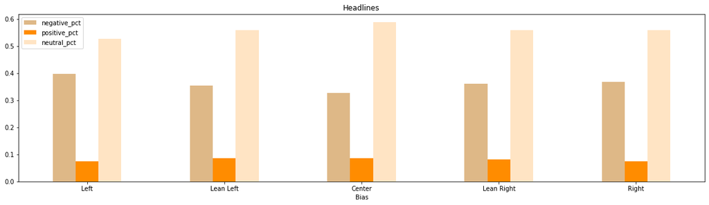

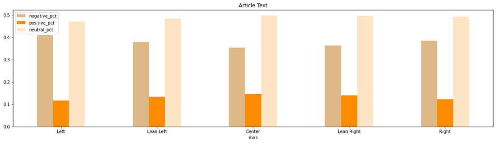

```python
import matplotlib.pyplot as plt
import numpy as np


myplot = hl[['Bias', 'negative_pct', 'positive_pct', 'neutral_pct']].copy()
myplot = myplot.groupby('Bias').agg('mean')
_ = myplot.plot(kind='bar', figsize=(20,5), title="Headlines", color=['burlywood', 'darkorange', 'bisque']).set_xticklabels(labels=myplot.index.unique(), rotation = 0)

adplot = ad[['Bias', 'negative_pct', 'positive_pct', 'neutral_pct']].copy()
adplot = adplot.groupby('Bias').agg('mean')
_=adplot.plot(kind='bar', figsize=(20,5), title="Article Text", color=['burlywood', 'darkorange', 'bisque']).set_xticklabels(labels=myplot.index.unique(), rotation = 0)
```

### Headlines and Article Sentiment by Week

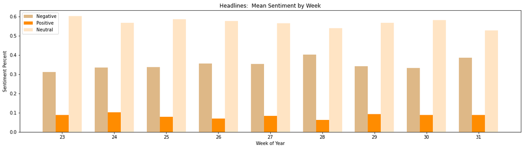

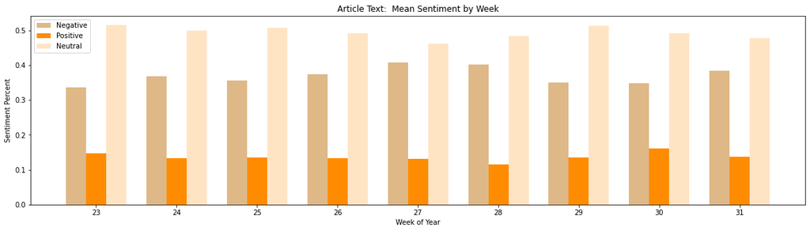

```python
## Sentiment by Week of Year.

def triple_bar_plot(df, timespan='week'):

  import matplotlib.pyplot as plt

  plt.figure(figsize=(20,5))
  myplot = df

  if timespan.lower() == 'week':
    myplot.Pub_Date = myplot.Pub_Date.dt.isocalendar().week
    rotation = 0
  if timespan.lower() == 'day':
    myplot.Pub_Date = myplot.Pub_Date.dt.date
    rotation = 90

  myplot = myplot.groupby('Pub_Date').agg('mean')

  N = len(myplot.reset_index().Pub_Date.unique())
  ind = np.arange(N)
  width = 0.25

  xvals =  myplot.negative_pct
  bar1 = plt.bar(ind, xvals, width, color = 'burlywood')

  yvals =  myplot.positive_pct
  bar2 = plt.bar(ind+width, yvals, width, color='darkorange')

  zvals =  myplot.neutral_pct
  bar3 = plt.bar(ind+width*2, zvals, width, color = 'bisque')

  plt.xlabel("{} of Year".format(timespan.title()))
  plt.ylabel('Sentiment Percent')

  plt.xticks(ind+width, myplot.reset_index().Pub_Date.unique(), rotation=rotation)
  plt.legend( (bar1, bar2, bar3), ('Negative', 'Positive', 'Neutral') )

  return plt

## Headline Plot
plt = triple_bar_plot(hl[['Pub_Date', 'negative_pct', 'positive_pct', 'neutral_pct']].copy())
plt.title("Headlines:  Mean Sentiment by Week")

## Article Text Plot
plt = triple_bar_plot(ad[['Pub_Date', 'negative_pct', 'positive_pct', 'neutral_pct']].copy())
plt.title("Article Text:  Mean Sentiment by Week")

plt.show()
```

### Headlines and Article Sentiment by Day

The chart shows 11 June 2022 as one of the most negative news days, but it is significant to note the corpus for that day is made up of only 2 articles, and both describe the war in Ukraine. While that is exceedingly negative, that day does not have a balance of articles as other days in the dataset.

August 6, another negative news day included articles about the war in Ukraine and China's change in their US foreign policy, in retaliation to Speaker Nancy Pelosi's visit to Taiwan.

Other notable negative news days include 7/5 where news is characterized by extremely high oil prices, the mass shooting in Highland Park, Illinois, and a falling stock market; and 6/26 with news of demonstrations from the Supreme Court Decision overturning Roe vs Wade, high oil prices, and the war in Ukraine.

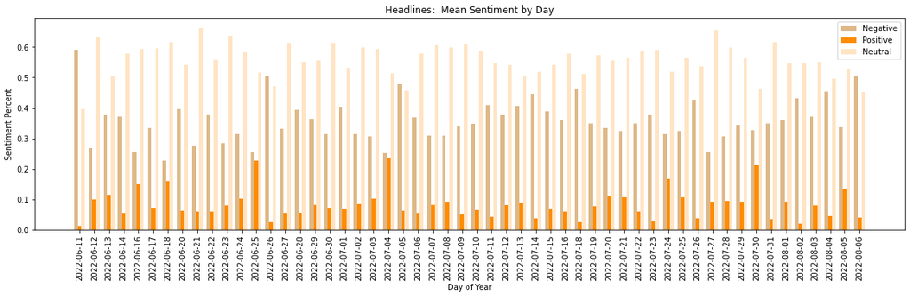

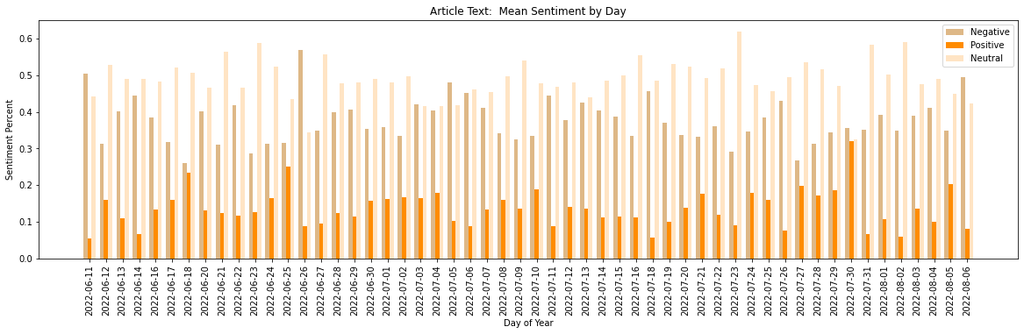

```python
## Sentiment Plots by Day

## Headline Plot
plt = triple_bar_plot(hl[['Pub_Date', 'negative_pct', 'positive_pct', 'neutral_pct']].copy(), 'Day')
plt.title("Headlines:  Mean Sentiment by Day")

## Article Text Plot
plt = triple_bar_plot(ad[['Pub_Date', 'negative_pct', 'positive_pct', 'neutral_pct']].copy(), 'Day')
plt.title("Article Text:  Mean Sentiment by Day")

plt.show()
```

### Negative, Positive, and Neutral Ratings by Bias by Week

A graph like this is good for showing exceptions to the average. We can clearly see the groupings of Negative, Positive, and Neutral bars. Any bars that exceed the thresholds of the others for their week can be investigated.

For example, the Left appears to be exceedingly negative on week 30. Looking into the news articles by the Left for that week, we see subjects such as Monkeypox, Covid, and the January 6th insurrection. The right bias was more likely to discuss the economy, with a mention of covid.

[figure not shown]

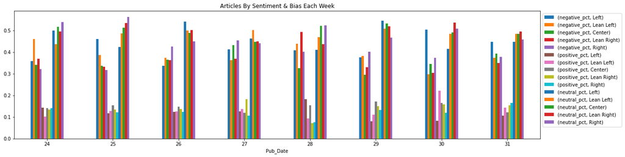

```python
## Seniment by Bias by Week
import matplotlib.pyplot as plt
plt.figure(figsize=(20,5))

myplot = hl[['Pub_Date', 'Bias', 'negative_pct', 'positive_pct', 'neutral_pct']].copy()
myplot.Pub_Date = myplot.Pub_Date.dt.isocalendar().week
myplot = myplot.groupby(['Pub_Date', 'Bias']).agg('mean').unstack().dropna()

myplot.plot(kind='bar', figsize=(20, 5), title='Headlines By Sentiment & Bias Each Week').set_xticklabels(adplot.index.sort_values(), rotation=0)
plt.legend(bbox_to_anchor=(1.0, 1.0))

adplot = ad[['Pub_Date', 'Bias', 'negative_pct', 'positive_pct', 'neutral_pct']].copy()
adplot.Pub_Date = adplot.Pub_Date.dt.isocalendar().week
adplot = adplot.groupby(['Pub_Date', 'Bias']).agg('mean').unstack().dropna()

adplot.plot(kind='bar', figsize=(20, 5), title='Articles By Sentiment & Bias Each Week').set_xticklabels(adplot.index.sort_values(), rotation=0)
plt.legend(bbox_to_anchor=(1.0, 1.0))
```

### Headlines and Articles Most Negative

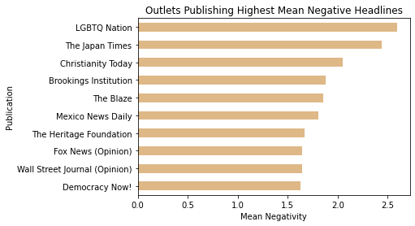

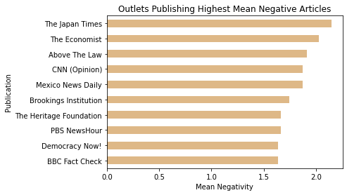

```python
import matplotlib.pyplot as plt

## Who Publishes News Ranked Negative
whoisnegativeH = hl[['Publication', 'Bias', 'negative', 'neutral', 'positive']].groupby(['Publication', 'Bias']).agg(['mean']).reset_index().dropna().copy()
whoisnegativeA = ad[['Publication', 'Bias', 'negative', 'neutral', 'positive']].groupby(['Publication', 'Bias']).agg(['mean']).reset_index().dropna().copy()

## Prepare Plots
plt.figure(figsize=(10,5))

_ =whoisnegativeH[['Publication', 'Bias', 'negative']].nlargest(10, ('negative', 'mean'))\
               .set_index('Publication')\
               .sort_values(by=('negative', 'mean'))\
               .plot.barh(color='burlywood', legend=False)

plt.title('Outlets Publishing Highest Mean Negative Headlines')
plt.ylabel('Publication')
plt.xlabel('Mean Negativity')

_ =whoisnegativeA[['Publication', 'Bias', 'negative']].nlargest(10, ('negative', 'mean'))\
              .set_index('Publication')\
              .sort_values(by=('negative', 'mean'))\
              .plot.barh(color='burlywood', legend=False)

plt.title('Outlets Publishing Highest Mean Negative Articles')
plt.ylabel('Publication')
plt.xlabel('Mean Negativity')

plt.savefig('/content/NegativeHeadlinesByPublisher.png')
```

### Headlines and Articles Most Positive

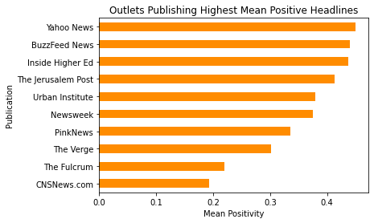

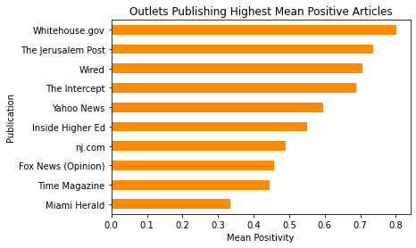

```python
## Who Publishes News ranked Positive
whoispositiveH = hl[['Publication', 'Bias', 'negative_pct', 'neutral_pct', 'positive_pct']].groupby(['Publication', 'Bias']).agg(['mean']).reset_index().dropna().copy()
whoispositiveA = ad[['Publication', 'Bias', 'negative_pct', 'neutral_pct', 'positive_pct']].groupby(['Publication', 'Bias']).agg(['mean']).reset_index().dropna().copy()

## Need to understand the scale.  Is 2.5 higher or lower than -2.5...
## Want to color the bars by Bias:  color=['red', 'green', 'blue'] when 'Bias' = left, right, center
whoispositiveH[['Publication', 'Bias', 'positive_pct']].nlargest(10, ('positive_pct', 'mean'))\
              .set_index('Publication')\
              .sort_values(by=('positive_pct', 'mean'))\
              .plot.barh(color='darkorange', legend=False)

plt.title('Outlets Publishing Highest Mean Positive Headlines')
plt.ylabel('Publication')
plt.xlabel('Mean Positivity')

whoispositiveA[['Publication', 'Bias', 'positive_pct']].nlargest(10, ('positive_pct', 'mean'))\
              .set_index('Publication')\
              .sort_values(by=('positive_pct', 'mean'))\
              .plot.barh(color='darkorange', legend=False)

plt.title('Outlets Publishing Highest Mean Positive Articles')
plt.ylabel('Publication')
plt.xlabel('Mean Positivity')

plt.show()
plt.savefig('/content/PositiveHeadlinesByPublisher.png')
```

## General Lookups

Look Up a particular Publication

```python
with pd.option_context('display.max_colwidth', None):
  display(hl.loc[hl.Publication == 'Yahoo News'])
```

|  | Title | Pub_Date | Publication | Bias | negative | neutral | positive | negative_pct | neutral_pct | positive_pct |
| --- | --- | --- | --- | --- | --- | --- | --- | --- | --- | --- |
| 1861 | Inflation Reduction Act would lead to $1,800 in savings for average household, analysis finds | 2022-08-03 08:16:56-07:00 | Yahoo News | Lean Left | -2.858557 | 1.396212 | 1.209594 | 0.007699 | 0.542312 | 0.449989 |

```python
with pd.option_context('display.max_colwidth', None):
  display(hl.loc[hl.Publication == 'LGBTQ Nation'])
```

|  | Title | Pub_Date | Publication | Bias | negative | neutral | positive | negative_pct | neutral_pct | positive_pct |
| --- | --- | --- | --- | --- | --- | --- | --- | --- | --- | --- |
| 568 | The never-repealed laws banning same-sex marriage & sodomy are now a ticking time bomb | 2022-06-27 11:48:35-07:00 | LGBTQ Nation | Left | 2.59064 | 0.1984 | -3.0221 | 0.913179 | 0.083487 | 0.003334 |

Look up Articles by week and bias sorted by negativity

```python
with pd.option_context('display.max_colwidth', None):
  display(ad.loc[ad.Pub_Date.dt.isocalendar().week == 30].loc[ad.Bias=='Right'].sort_values(by='negative_pct'))
```

|  | Description | Pub_Date | Publication | Bias | negative | neutral | positive | negative_pct | neutral_pct | positive_pct |
| --- | --- | --- | --- | --- | --- | --- | --- | --- | --- | --- |
| 1772 | Referring to Alexis de Tocqueville’s study of America in the 1830’s, Dr. Carson notes the great role of churches in helping Americans establish a sense of morality and duty. He says it is not simply a… | 2022-07-28 08:29:26-07:00 | CBN | Right | -2.730472 | 0.838502 | 1.900875 | 0.007187 | 0.255010 | 0.737803 |
| 1732 | Washington, D.C., Mayor Muriel Bowser requested the deployment of the city’s National Guard troops to address the influx of migrants bused from Texas and Arizona.\n\n“We’ve had a number of discussions… | 2022-07-28 17:50:36-07:00 | The Daily Caller | Right | -2.378453 | 1.936466 | 0.294152 | 0.011076 | 0.828570 | 0.160355 |
| 1592 | The Senate Wednesday passed a bill aimed at increasing U.S. competition with China by a 64-33 vote, sending the $250 billion measure to the House of Representatives.\n\nThe bill, officially called the… | 2022-07-27 11:53:47-07:00 | Fox News (Online News) | Right | -2.315701 | 1.251060 | 1.254066 | 0.013906 | 0.492306 | 0.493788 |
| 1672 | Former President Trump on Tuesday is expected to focus on law and order in his first speech in Washington, D.C., since leaving office in January 2021, with a source familiar telling Fox News he sees t… | 2022-07-26 06:15:03-07:00 | Fox News (Online News) | Right | -2.175540 | 1.568277 | 0.317054 | 0.018066 | 0.763465 | 0.218469 |
| 1530 | The Biden administration wants to provide temporary identification cards to illegal immigrants who are awaiting final decisions on their cases, Axios reported.\n\nOfficials are considering a pilot pro… | 2022-07-25 11:54:42-07:00 | Newsmax (News) | Right | -1.769899 | 1.400469 | 0.327978 | 0.030335 | 0.722468 | 0.247196 |
| 1778 | It does look that way. Go read this basic timeline from Allahpundit, starting with a legislative threat McConnell issued at the end of last month. That ultimatum appeared to have worked, with Manchin … | 2022-07-28 08:07:28-07:00 | Townhall | Right | -1.351543 | 0.928265 | 0.306368 | 0.062410 | 0.610043 | 0.327547 |
| 1588 | WNBA star Brittney Griner, who has been detained in Russia on drug charges since February, could return to the U.S. after Secretary of State Antony Blinken revealed Wednesday that the Biden administra… | 2022-07-27 12:47:51-07:00 | Fox News (Online News) | Right | -1.074002 | 1.196557 | -0.269662 | 0.077399 | 0.749597 | 0.173004 |
| 1769 | Sen. Marco Rubio, R-Fla., ripped President Joe Biden's phone call with China's President Xi Jinping.\n\nThe call, which was scheduled for Thursday morning, is a "win" for China, Rubio said.\n\n"The ph… | 2022-07-28 10:09:06-07:00 | Newsmax (News) | Right | -0.930978 | 0.684189 | 0.249709 | 0.107697 | 0.541577 | 0.350726 |
| 1693 | The CNN journalist best known for reporting from the burning scene of "fiery but mostly peaceful protests" following the justified non-fatal police shooting of armed sexual-assault suspect Jacob Blake… | 2022-07-29 13:12:55-07:00 | Washington Free Beacon | Right | -0.703464 | 0.954566 | -0.329367 | 0.129826 | 0.681450 | 0.188725 |
| 1706 | The gloves have come off in the runoff election between Republican Senator Kelly Loeffler and her opponent, Reverend Raphael Warnock of the Ebenezer Baptist Church in Atlanta.\n\nOver the past week, L… | 2022-07-29 08:33:43-07:00 | National Review | Right | -0.343901 | 1.369033 | -1.265837 | 0.144031 | 0.798681 | 0.057288 |
| 1710 | Democrat President Joe Biden’s administration will fill gaps in certain areas of former President Donald Trump’s border wall on the U.S. southern border as the illegal immigration crisis hits Washingt… | 2022-07-29 07:49:31-07:00 | The Daily Wire | Right | -0.507677 | 1.123752 | -0.800975 | 0.145837 | 0.745398 | 0.108765 |
| 1735 | Washington, D.C., mayor Muriel Bowser has asked that the D.C. National Guard be activated indefinitely to help the district respond to an influx of illegal immigrants arriving by bus, according to a r… | 2022-07-28 15:51:33-07:00 | National Review | Right | -0.038282 | 1.525966 | -1.581320 | 0.166867 | 0.797469 | 0.035665 |
| 1611 | Disgraced television host Chris Cuomo announced Tuesday night that he has landed a new job in the news media and that he is going to try to be fair after he was routinely criticized for being a hardco… | 2022-07-27 07:54:40-07:00 | The Daily Wire | Right | -0.509814 | 0.698750 | -0.375011 | 0.182050 | 0.609627 | 0.208322 |
| 1619 | When asked if Congress will ever balance the budget, Senator Chuck Grassley (R-Iowa) pointed to the proposed and long-debated balance budget amendment as the proper means of doing so.\n\nAt the Capito… | 2022-07-27 06:49:47-07:00 | CNSNews.com | Right | -0.227436 | 1.065484 | -1.105648 | 0.197670 | 0.720193 | 0.082137 |
| 1739 | Democrats are leading in the tight midterm race with a 4% edge over the GOP on the generic congressional ballot, as voters rank abortion as a leading issue over inflation.\n\nA new Suffolk University/… | 2022-07-28 15:28:59-07:00 | Fox News (Online News) | Right | -0.206146 | 1.030782 | -0.990117 | 0.204015 | 0.702834 | 0.093151 |
| 1721 | An edit war broke out on Wikipedia this week over the definition of “recession,” as the Biden administration and the corporate media take the unprecedented step of denying the U.S. is in recession eve… | 2022-07-29 07:04:51-07:00 | Breitbart News | Right | -0.249001 | 0.589817 | -0.404850 | 0.239847 | 0.554918 | 0.205235 |
| 1631 | President Joe Biden is almost pretty much out of the woods when it comes to recovering from COVID-19, or so we're told. His symptoms are nearly "resolved," though it's worth reminding time and time ag… | 2022-07-26 16:55:37-07:00 | Townhall | Right | -0.189307 | 0.619589 | -0.522861 | 0.252411 | 0.566769 | 0.180820 |
| 1669 | As the monkeypox virus becomes a health concern that Americans seem to hear about more and more, what are some of the best practices for avoiding the virus — and is it time to worry?\n\nFox News Digit… | 2022-07-26 06:51:32-07:00 | Fox News (Online News) | Right | -0.086384 | 0.791761 | -0.924274 | 0.260481 | 0.626829 | 0.112690 |
| 1585 | Florida Gov. Ron DeSantis used President Joe Biden’s recent COVID-19 diagnosis to ridicule vaccine mandates.\n\nAs he began remarks to the media Wednesday morning in Tampa, Florida, DeSantis commented… | 2022-07-27 12:57:49-07:00 | Newsmax (News) | Right | -0.070775 | 0.772382 | -0.763999 | 0.261530 | 0.607715 | 0.130755 |
| 1775 | White House Press Secretary Karine Jean-Pierre said Wednesday that the White House is not redefining recession one day before it was reported that the GDP (Gross Domestic Product) shrank by 0.9 percen… | 2022-07-28 08:20:36-07:00 | CNSNews.com | Right | 0.092536 | 0.988504 | -1.333370 | 0.271003 | 0.663877 | 0.065120 |
| 1686 | Immigration and Customs Enforcement (ICE) agents found 73 illegal immigrants in homes believed to be operated by human smugglers in an affluent area of Washington D.C.\n\nSixty adults and 13 children … | 2022-07-29 14:00:31-07:00 | The Daily Wire | Right | 0.396586 | 1.219763 | -1.636615 | 0.293372 | 0.668221 | 0.038407 |
| 1583 | The Federal Reserve raised interest rates by 0.75% on Wednesday as the central bank tries to fight inflation by decreasing consumer spending, but some economists aren’t convinced that it’ll be enough … | 2022-07-27 14:23:16-07:00 | The Daily Caller | Right | 0.293082 | 0.973670 | -1.449356 | 0.317447 | 0.626970 | 0.055583 |
| 1745 | President Joe Biden claimed that Thursday’s economic data showing the U.S. has entered a recession is “consistent with the transition to a stable, steady growth and lower inflation.”\n\nThe Biden admi… | 2022-07-28 14:56:24-07:00 | The Daily Wire | Right | 0.286598 | 0.545159 | -1.016740 | 0.389607 | 0.504566 | 0.105826 |
| 1638 | Nate Silver’s FiveThirtyEight website claims to use “statistical analysis to tell compelling stories about elections, politics, sports, science and life” and attempts to present itself as a moderate v… | 2022-07-26 14:44:32-07:00 | The Federalist | Right | 0.443527 | 0.707115 | -1.296623 | 0.403700 | 0.525453 | 0.070847 |
| 2009 | Illinois Democratic Rep. Chuy García used term for mentally disabled people that is considered offensive\n\nBy Timothy H.J. Nerozzi \| Fox News\n\nDemocratic Rep. Chuy García posted a profane response… | 2022-07-31 00:14:18-07:00 | Fox News (Online News) | Right | 0.623526 | 0.863126 | -1.759096 | 0.423182 | 0.537755 | 0.039063 |
| 1678 | More than 16,000 acres have burned as firefighters in Northern California continue to battle the Oak Fire near Yosemite National Park. \n\nThe number of personnel assigned to fight the blaze jumped fr… | 2022-07-25 17:55:12-07:00 | Fox News (Online News) | Right | 0.463791 | 0.545440 | -1.050098 | 0.433815 | 0.470722 | 0.095462 |
| 1741 | Illegal immigration in Arizona has apparently become so bad even a vulnerable midterm Democrat senator had to urge the Biden administration to pick up building a portion of former President Donald Tru… | 2022-07-28 15:05:33-07:00 | Newsmax (News) | Right | 0.540260 | 0.531627 | -1.295969 | 0.464939 | 0.460942 | 0.074119 |
| 1590 | Opponents of the CHIPS Act, which provides more than $70 billion in funding for domestic semiconductor manufacturing, have spent the past two weeks cycling through weak critiques that persuaded no one… | 2022-07-27 12:07:41-07:00 | The American Conservative | Right | 0.609617 | 0.565379 | -1.377195 | 0.477587 | 0.456920 | 0.065492 |
| 1722 | The death toll from catastrophic flooding in eastern Kentucky has reached 15 people. \n\nGov. Andy Beshear told The Associated Press on Friday that the number is expected to more than double and would… | 2022-07-29 06:51:13-07:00 | Fox News (Online News) | Right | 0.719031 | 0.695507 | -1.520954 | 0.480028 | 0.468868 | 0.051104 |
| 1627 | The White House attempted to gaslight Americans by casting confusion over the meaning of a recession. But did it take its cues from a major publication funded by liberal billionaire George Soros? \n\n… | 2022-07-26 18:05:05-07:00 | NewsBusters | Right | 0.690539 | 0.621381 | -1.554368 | 0.490408 | 0.457639 | 0.051953 |
| 1540 | On the menu today: In a week full of big economic-news releases, on Thursday morning, the U.S. will learn if we’ve experienced two consecutive quarters of the GDP shrinking — the traditional definitio… | 2022-07-25 11:26:52-07:00 | National Review | Right | 0.635989 | 0.501827 | -1.206344 | 0.491909 | 0.430149 | 0.077942 |
| 2022 | Former President Donald Trump on Friday said that House Speaker Nancy Pelosi, D-Calif., should not travel to Taiwan during her trip to Asia this week.\n\nPelosi is leading a legislative delegation on … | 2022-07-29 14:21:09-07:00 | Newsmax (News) | Right | 0.956898 | 0.917840 | -2.171956 | 0.498638 | 0.479538 | 0.021824 |
| 1589 | The University of Chicago’s Institute of Politics has a new poll out, and the numbers are pretty shocking — but not particularly surprising or even discouraging, if you understand the long view.\n\nAs… | 2022-07-27 12:15:04-07:00 | The American Spectator | Right | 0.578291 | 0.319968 | -1.062709 | 0.508613 | 0.392825 | 0.098562 |
| 1643 | Former President Donald Trump, in his first trek to Washington since the end of his presidency, delivered blistering remarks on a country that had been "made great again" but has more recently become … | 2022-07-26 14:06:30-07:00 | Newsmax (News) | Right | 0.578407 | 0.266852 | -1.039733 | 0.517981 | 0.379321 | 0.102698 |
| 1780 | Republicans are not pleased with the prospect of a revived version of Build Back Better after Sen. Joe Manchin, D-W.Va. and Senate Majority Leader Chuck Schumer announced they came to an agreement on … | 2022-07-28 07:13:45-07:00 | Fox News (Online News) | Right | 0.859913 | 0.695570 | -1.753538 | 0.520364 | 0.441503 | 0.038133 |
| 1625 | Why don’t the Democrats have better leaders?\n\nWe know why the Republicans don’t have better leaders: The GOP turned itself into a Donald Trump personality cult, and would-be alternatives such as Ron… | 2022-07-27 06:21:22-07:00 | National Review | Right | 0.720249 | 0.490896 | -1.426303 | 0.523030 | 0.415834 | 0.061135 |
| 1550 | As President Biden, who is 79 years old, recovers from his recent diagnosis of COVID-19, some Americans may wonder about some of the other illnesses that previous U.S. presidents battled over the year… | 2022-07-25 07:33:52-07:00 | Fox News (Online News) | Right | 0.851251 | 0.659398 | -1.686201 | 0.525073 | 0.433410 | 0.041516 |
| 1689 | It is almost comical how much work the Biden administration is putting into denying that the U.S. economy has entered a recession.\n\nHere is what is not in dispute:\n\nOne, real GDP is contracting an… | 2022-07-29 13:53:45-07:00 | National Review | Right | 0.822378 | 0.423292 | -1.402181 | 0.562099 | 0.377130 | 0.060771 |
| 1682 | The former chief editor of the Chinese Communist Party's state tabloid, the Global Times, suggested the country shoot down U.S. Speaker of the House Nancy Pelosi for visiting Taiwan if her plane refus… | 2022-07-29 14:12:42-07:00 | Fox News (Online News) | Right | 1.321333 | 0.944580 | -2.499358 | 0.585480 | 0.401690 | 0.012829 |
| 1536 | Immunologists and scientists have been concerned about the latest COVID subvariant, BA.5. Data has shown that it is more contagious than previous strains and that it can not only get by antibodies cre… | 2022-07-25 11:42:04-07:00 | The Daily Wire | Right | 0.987753 | 0.460546 | -1.701763 | 0.603076 | 0.355967 | 0.040957 |
| 1607 | Federal Reserve Chair Jerome Powell responded to a report from Senate Republicans claiming that the central bank failed to combat a Chinese government information theft campaign by calling it “unfair,… | 2022-07-27 09:16:23-07:00 | The Daily Wire | Right | 1.323362 | 0.675992 | -2.150687 | 0.643330 | 0.336732 | 0.019938 |
| 1537 | CLAIM: President Donald Trump failed to stop rioters who were “savagely beating and killing law enforcement officers.”\n\nVERDICT: FALSE. While some rioters attacked police, they did not kill any; the… | 2022-07-25 11:38:52-07:00 | Breitbart Fact Check | Right | 1.442195 | 0.458804 | -2.068834 | 0.712298 | 0.266428 | 0.021274 |
| 1559 | It’s here. You’ve all known for months that the country was barreling towards a recession. Everyone feels it. Americans have been seeing their paychecks get cannibalized by inflation. Filling up one’s… | 2022-07-25 06:21:47-07:00 | Townhall | Right | 1.650719 | 0.098331 | -1.913488 | 0.806412 | 0.170751 | 0.022837 |
| 1660 | America is increasingly outraged by the manner in which radical Big Tech leftists are censoring conservative and Christian leaders and organizations on nearly every major social media platform. \n\nBu… | 2022-07-26 10:10:04-07:00 | NewsBusters | Right | 2.275167 | 0.249664 | -2.905809 | 0.879082 | 0.115975 | 0.004943 |
| 1692 | Make no mistake: the so-called Inflation Reduction Act unveiled Wednesday by Senate Majority Leader Chuck Schumer, (D-NY), and Sen. Joe Manchin, (D-WV), will do nothing that its supporters state — in … | 2022-07-29 13:22:56-07:00 | The Daily Signal | Right | 2.183084 | -0.019387 | -2.431927 | 0.892513 | 0.098649 | 0.008838 |
| 1749 | No matter how much the White House or its cronies in the corrupt corporate media try to cover up the nation’s economic crises, the U.S. economy is in fact in a recession.\n\nNot only did gross domesti… | 2022-07-28 13:15:23-07:00 | The Federalist | Right | 2.257112 | 0.055886 | -2.585652 | 0.894012 | 0.098938 | 0.007049 |

Look Up articles by Day, sorted by negativity

```python
with pd.option_context('display.max_colwidth', None):
  display(ad.loc[ad.Pub_Date.dt.date == pd.to_datetime('2022-06-26').date()].sort_values(by='negative_pct'))
```

|  | Description | Pub_Date | Publication | Bias | negative | neutral | positive | negative_pct | neutral_pct | positive_pct |
| --- | --- | --- | --- | --- | --- | --- | --- | --- | --- | --- |
| 469 | When I left the full-time practice of law and landed at National Review, my friends and colleagues Jay Nordlinger and Jonah Goldberg both independently gave me exactly the same advice. My job, they sa… | 2022-06-26 11:07:04-07:00 | The Dispatch | Lean Right | -1.489391 | 0.544866 | 1.004477 | 0.048182 | 0.368428 | 0.583390 |
| 467 | South Dakota Gov. Kristi Noem (R) on Sunday said she will ban telemedicine appointments with abortion care providers who prescribe pills online in the GOP-controlled state in the wake of the Supreme C… | 2022-06-26 11:12:40-07:00 | The Hill | Center | 0.400862 | 1.226340 | -1.807818 | 0.294740 | 0.672884 | 0.032376 |
| 474 | Protests and rallies continued Saturday in response to the Supreme Court’s ruling that ended constitutional protections for abortion rights, as states continue to adjust to a decision that overturned … | 2022-06-26 09:42:43-07:00 | Wall Street Journal (News) | Center | 0.719040 | 0.904600 | -1.771806 | 0.437305 | 0.526468 | 0.036226 |
| 470 | Noé was somewhere on the outskirts of the gritty southern Mexican city of Tapachula when he realised how difficult his journey to a new life in the US would be.\n\nJust days after crossing the border … | 2022-06-26 11:04:31-07:00 | BBC News | Center | 0.757154 | 0.587378 | -1.410486 | 0.510647 | 0.430911 | 0.058442 |
| 466 | The battlefield that is Ukraine is in the midst of another war. Yet, against expectations and with the current war in Ukraine starting its fifth month, no outcome is apparent. What is clear is how lit… | 2022-06-26 11:16:55-07:00 | National Review | Right | 1.294104 | 0.575501 | -2.111476 | 0.657626 | 0.320549 | 0.021825 |
| 473 | Protests over a US supreme court decision that overturned abortion rights continued across the country this weekend. In New York, thousands marched to voice their anger at the ruling that came at the … | 2022-06-26 09:44:35-07:00 | The Guardian | Lean Left | 1.308798 | 0.410823 | -1.839461 | 0.689503 | 0.280899 | 0.029598 |
| 468 | United Nations Secretary-General António Guterres called for debt relief for the world's poorest countries on Friday as he warned that an "unprecedented global food crisis" that is already ravaging mo… | 2022-06-26 11:09:13-07:00 | Common Dreams | Left | 1.526559 | 0.421595 | -2.257074 | 0.738573 | 0.244632 | 0.016795 |
| 471 | This year’s energy shock is the most serious since the Middle Eastern oil crises of 1973 and 1979. Like those calamities, it promises to inflict short-term pain and in the longer term to transform the… | 2022-06-26 11:01:55-07:00 | The Economist | Lean Left | 2.028894 | 0.075271 | -2.343637 | 0.866267 | 0.122802 | 0.010932 |
| 472 | A group of black-clad marchers turned violent Saturday night in Portland, Ore., smashing windows and scrawling graffiti on downtown businesses as protests continued to rage across the nation against … | 2022-06-26 09:51:27-07:00 | New York Post (News) | Lean Right | 2.264545 | 0.297500 | -2.702683 | 0.871967 | 0.121962 | 0.006071 |